# FakeNews

# Introdução

Nos foi introduzido, para a realização do trabalho, um dataset contendo dados de 30.000 estudantes aleatórios do ensino médio americano que possuem contas em uma rede social durante o ano de 2006. O nome da rede social foi mantido secreto para preservar a privacidade dos estudantes). Nosso objetivo com esse dataset era realizar a clusterização baseado nos conteúdos dos posts dos usuários.

# Método Utilizado

## Preparação dos dados

O primeiro foi realizar a leitura dos dados a partir do CSV e entender como estavam organizados.

```r
teens <- read.csv('snsdata.csv')
library(stats)
nrow(teens)
```

```
## [1] 30000
```

Os próximos passos da preparação foram retirar os NA’s e substituir os fatores do atributo “gender” para valores binários (fizemos isso para conseguirmos usar o kmeans futuramente).

```r
table(teens$gender, useNA = 'always')
```

```
##
##     F     M  <NA>
## 22054  5222  2724
```

```r
teens$female <- ifelse(teens$gender == "F" & !is.na(teens$gender),1,0)
teens$no_gender <- ifelse(is.na(teens$gender),1,0)
```

Com a preparação dos dados de gênero, conseguimos partimos para a idade dos estudantes.

```r
summary(teens$age)
```

```
##    Min. 1st Qu.  Median    Mean 3rd Qu.    Max.    NA's
##   3.086  16.312  17.287  17.994  18.259 106.927    5086
```

A partir da análise do atributo usando o summary, foi possível concluir que, no dataset, temos “estudantes” desde 3 até 106 anos. Para conseguir balancear isso, filtramos os dados pela data.

Com uma breve pesquisa no Google, conseguimos descobrir as idades médias de estudantes de High School dos EUA e usamos esses dados para fazer o filtro:

#### 9th grade => 13-14 anos

#### 10th grade => 14-15 anos

#### 11th grade => 15-16 anos

#### 12th grade => 16-17 anos

#### O estudante conclui o High School com idade entre 17 e 18 anos

#### Foram desconsiderados estudantes atrasados ou adiantados

```r
teens$age <- ifelse(
  teens$age >= 13 & teens$age < 18,
  teens$age,
  NA
)
summary(teens$age)
```

```
##    Min. 1st Qu.  Median    Mean 3rd Qu.    Max.    NA's
##   13.03   15.99   16.66   16.64   17.33   18.00   13043
```

Depois desse passo, agrupamos os estudantes a partir da sua média de idade total e a média de idade por ano de graduação.

```r
ave_age <- mean(teens$age, na.rm = TRUE)
ave_age
```

```
## [1] 16.64296
```

```r
ag <- aggregate(data = teens, age ~ gradyear, mean, na.rm = TRUE)
ag
```

```
##   gradyear      age
## 1     2006 17.08870
## 2     2007 17.53623
## 3     2008 16.74510
## 4     2009 15.80434
```

Fizemos então a remoção dos exemplos com valores de idade inadequados.

```r
nrow(teens)
```

```
## [1] 30000
```

```r
teens <- teens[!is.na(teens['age']),]
rownames(teens) <- 1:nrow(teens)
nrow(teens)
```

```
## [1] 16957
```

## Construção do Modelo

Começamos a construção fazendo a normalização dos dados.

```r
interests <- teens[5:40]
interests_z <- as.data.frame(lapply(interests, scale))
summary(interests_z[5:10])
```

```
##    volleyball         swimming       cheerleading        baseball
##  Min.   :-0.2375   Min.   :-0.266   Min.   :-0.2239   Min.   :-0.2178
##  1st Qu.:-0.2375   1st Qu.:-0.266   1st Qu.:-0.2239   1st Qu.:-0.2178
##  Median :-0.2375   Median :-0.266   Median :-0.2239   Median :-0.2178
##  Mean   : 0.0000   Mean   : 0.000   Mean   : 0.0000   Mean   : 0.0000
##  3rd Qu.:-0.2375   3rd Qu.:-0.266   3rd Qu.:-0.2239   3rd Qu.:-0.2178
##  Max.   :19.7433   Max.   :55.920   Max.   :15.9508   Max.   :22.4782
##      tennis            sports
##  Min.   :-0.1733   Min.   :-0.313
##  1st Qu.:-0.1733   1st Qu.:-0.313
##  Median :-0.1733   Median :-0.313
##  Mean   : 0.0000   Mean   : 0.000
##  3rd Qu.:-0.1733   3rd Qu.:-0.313
##  Max.   :24.3151   Max.   :23.857
```

Depois desse ponto, aplicamos o COTOVELO.

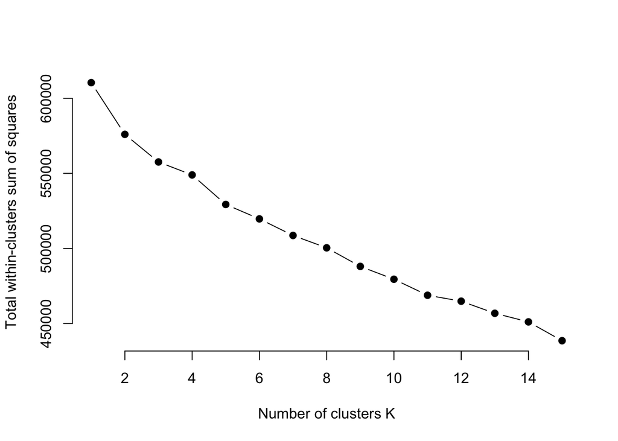

```r
set.seed(123)
models <- sapply(
  1:15,
  function(k){kmeans(interests_z, k, nstart=1)$tot.withinss}
)
plot(1:15, models, type='b', pch = 19, frame = FALSE,
     xlab='Number of clusters K',
     ylab='Total within-clusters sum of squares')
abline(v = 0, lty =0)
```

Geramos o modelo, com k = 5.

```r
teen_clusters <- kmeans(interests_z, 5)
```

E, por último, criamos a visualização dos dados.

```r
# install.packages("rlang")
# install.packages("devtools")
# devtools::install_github("kassambara/ggpubr")
# devtools::install_github("kassambara/factoextra")
library(factoextra)
```

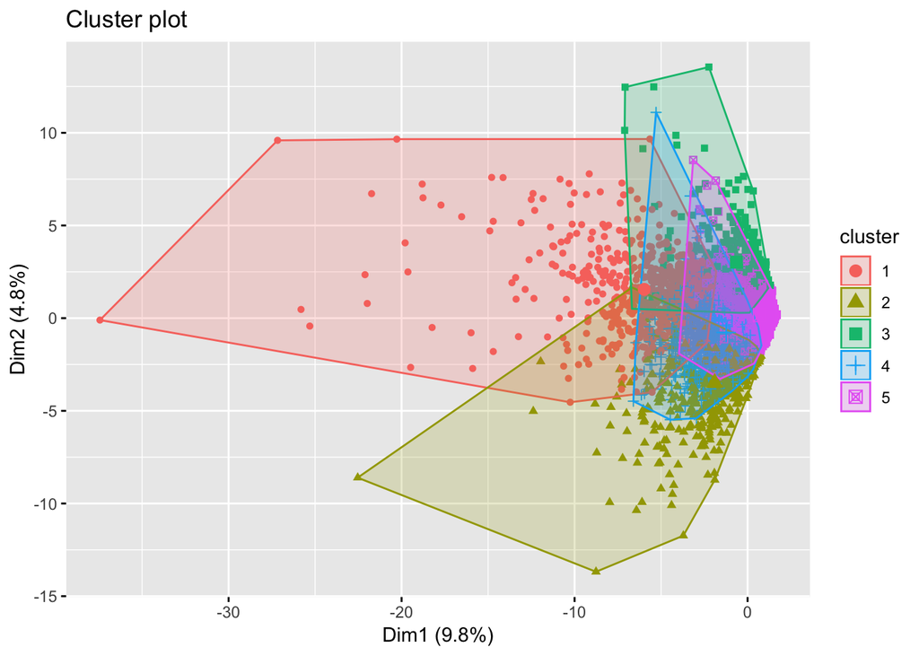

```r
fviz_cluster(
  teen_clusters,
  interests_z,
  geom = 'point',
  show.clust.cent = TRUE
)
```

## Análise dos resultados

Iniciamos checando o tamanho dos clusters.

```r
teen_clusters$size
```

```
## [1]   679   593   380  2791 12514
```

```r
teens$cluster <- teen_clusters$cluster
teens[1:5, c('cluster', 'gender', 'age', 'friends')]
```

```
##   cluster gender    age friends
## 1       5      F 17.158      27
## 2       5      M 17.906      23
## 3       5      F 17.199       4
## 4       5      F 16.810       7
## 5       5      F 17.818       0
```

Identificação das idades por cluster.

```r
aggregate(data = teens, age ~ cluster, mean)
```

```
##   cluster      age
## 1       1 16.60101
## 2       2 16.51184
## 3       3 16.78540
## 4       4 16.59297
## 5       5 16.65828
```

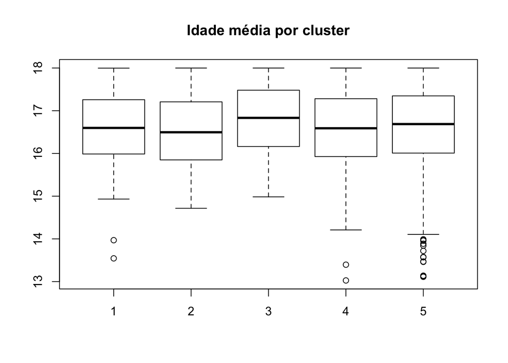

```r
boxplot(split(teens$age,teens$cluster),main='Idade média por cluster')
```

Identificação do número de amigos por cluster

```r
aggregate(data = teens, friends ~ cluster, mean)
```

```
##   cluster  friends
## 1       1 32.80412
## 2       2 41.10624
## 3       3 34.80000
## 4       4 40.32247
## 5       5 30.24165
```

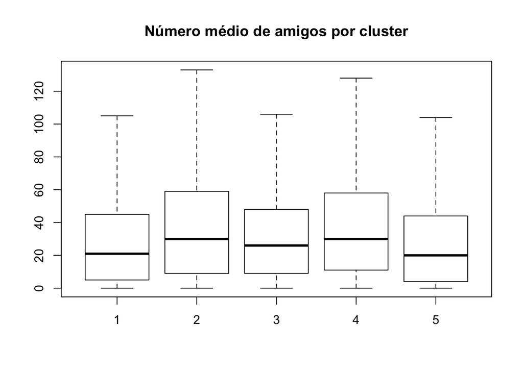

```r
boxplot(split(teens$friends,teens$cluster), outline=FALSE,main='Número médio de amigos por cluster')
```

E, por último, a identificação da quantidade de mulheres por cluster.

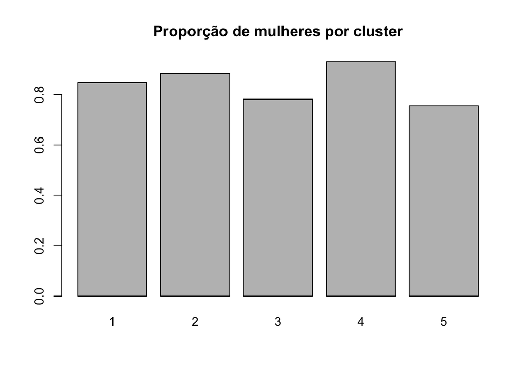

```r
aux <- aggregate(data = teens, female ~ cluster, mean)
barplot(aux$female, names.arg = c('1','2','3','4','5'), main = 'Proporção de mulheres por cluster')
```